# Wrangle Report

This report communicates the insights and displays the visualizations produced from the wrangled data.

The dataset that was wrangled (and analyzed and visualized) is the tweet archive of the Twitter account @dog_rates, also Known as WeRateDogs. This twitter account rates pepole's dogs with a humorous comment about the dog. These ratings almost always have a denominator of 10. the numerators, thought? Almost always greater than 10. 11/10, 12/10, 13/10, etc. Why? Because *"they're good dogs Brent."* WeRateDogs has over 4 millino followers and has received international media coverage.

## Storing Data

The cleaned data was stored in a CSV file with the main one named `twitter_archive_master.csv`

## Analyzing and Visualizing Data.

The cleaned data was analyzed and insights regarding the following were concluded:

- Ratings Distribution
- The percentage of different dog stages
- The relationship between retweet count and favorite count.
- Ratings Distribution
  - A bar was drawn to represent the ratings distribution

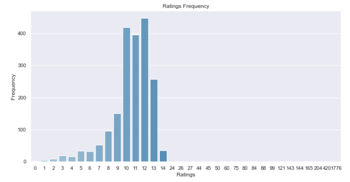

  *A pie chart was drawn to represent the findings*

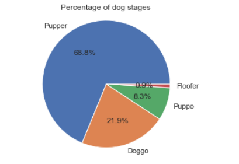

  *insights*
  - Pupper was found to have the highest percentage among other dog stages with a share of 68.8%
  - Doggo was found have 21.9%
  - Puppo was found have 8.3 %
  - Floofer was found to have the lowest percentage among other dog stages with a share of 0.9%
- The relationship between retweet count and favorite count. *A scatter plot was drawn to represent the findings*

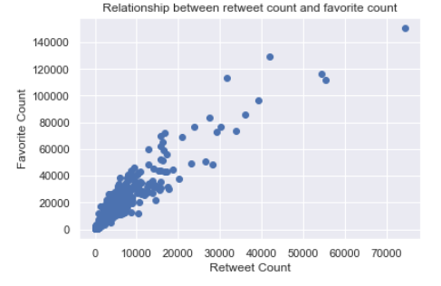

  *insights* : From the previous scatter plot it could be concluded the there is a linear relationship between retweet count and favorite count.